```
Ecole Centrale Nantes
Option InfoIA
PAPY: Programmation avancée python
CM2
Année 2022-2023
Auteur: Lucas Lestandi
lucas.lestandi@ec-nantes.fr
V1.0
```

# Chapitre 2 : Structuration et types de données

**Contenu**

- Variables, références et gestion de la mémoire
- Programmation fonctionnelle
- Programmation orientée objet (OOP) : les classes
- Conseils généraux pour la programmation

**Rappel : les types de base en python**

- `int` (entier)
- `float` (flottant)
- `str` (chaîne de caractères)
- `bool` (booléen)
- `list` (liste)
- `tuple` (tuple)
- `complex` (complexe)

## Variables, références et gestion de la mémoire

### Variables et affectation

> En python tout est objet $\Longrightarrow$ la variable `v` peut changer de type.

> **Definition:** *Une variable est un identificateur associé à une valeur. En Python, c’est une référence d’objet.*

```python
# 格式化的字符串文字前缀为’f’和接受的格式字符串相似str.format()。
# 它们包含由花括号包围的替换区域。替换字段是表达式，在运行时进行评估，然后使用format()协议进行格式化。
v=1
print(f"{v=},{type(v)}")
v="bonjour"
print(f"{v=},{type(v)}")
def v(param) : return None
print(f"{v=},\t{v(1)=},\t{type(v)}")
```

```
v=1,<class 'int'>
v='bonjour',<class 'str'>
v=<function v at 0x000001CB509AB040>,	v(1)=None,	<class 'function'>
```

**Sytème d'affectation des variables immutables**

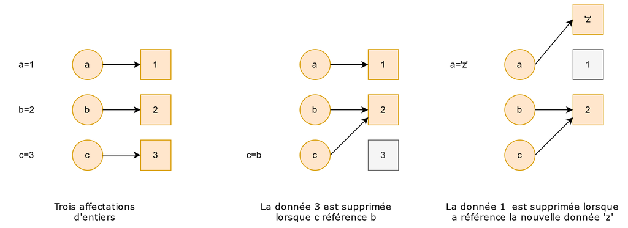

```python
a=1
b=2
c=3
print(f"{a=}, {b=}, {c=}")
```

```
a=1, b=2, c=3
```

```python
c=b
print(f"{a=}, {b=}, {c=}")
```

```
a=1, b=2, c=2
```

```python
a='z'
print(f"{a=}, {b=}, {c=}")
```

```
a='z', b=2, c=2
```

### Mutables et non-mutables

> *Les variables simples vue jusqu'ici sont dites **non-mutable** i.e.*
> 1. on ne modifie jamais le contenu d'une case mémoire
> 2. on affecte la variable à une nouvelle case

> *Il existe des objets dits **mutables**, dont le contenu est directement modifié.*

> Par exemple les listes

> ```
> ma_liste=[1,"chaine"]
> ```

```python
# On peut modifier la liste à la volée
L=[1,2,3]
L.append("nouvel élément")
print(L[:])
print(L.pop())
print(L)
```

```
[1, 2, 3, 'nouvel élément']
nouvel élément
[1, 2, 3]
```

#### Les listes, mutable par excellence

```python
L=[1,2,3]
L2=L #on crée une nouvelle référence
print(L==L2)
```

```
True
```

> ⚠️ Toute modification par l'un des "pointeurs" entraine une modification de la liste pointée.

```python
# id() 函数返回对象的唯一标识符，标识符是一个整数。
# id() 函数用于获取对象的内存地址。
L2[2]=10
print(L==L2, id(L)==id(L2))
print(L)
```

```
True True
[1, 2, 10]
```

```python
L2=4 #on change l'affectation de la variable
print(L==L2)
L2
```

```
False
```

```
4
```

```python
#Si on veut créer une copie de la liste et pas un pointeur

#Copie simple
Lcopie=L[:]
print(id(L))
print(id(Lcopie))
print("Les deux variables ont la même addresse mémoire ?",id(Lcopie)==id(L))
```

```
1972742207360
1972741946240
Les deux variables ont la même addresse mémoire ? False
```

```python
# Par le module copie
import copy
Lcopie=copy.copy(L) #shallow
print(id(L))
print(id(Lcopie))
print("Les deux variables ont la même addresse mémoire ?",id(Lcopie)==id(L))
```

```
1972742207360
1972742457664
Les deux variables ont la même addresse mémoire ? False
```

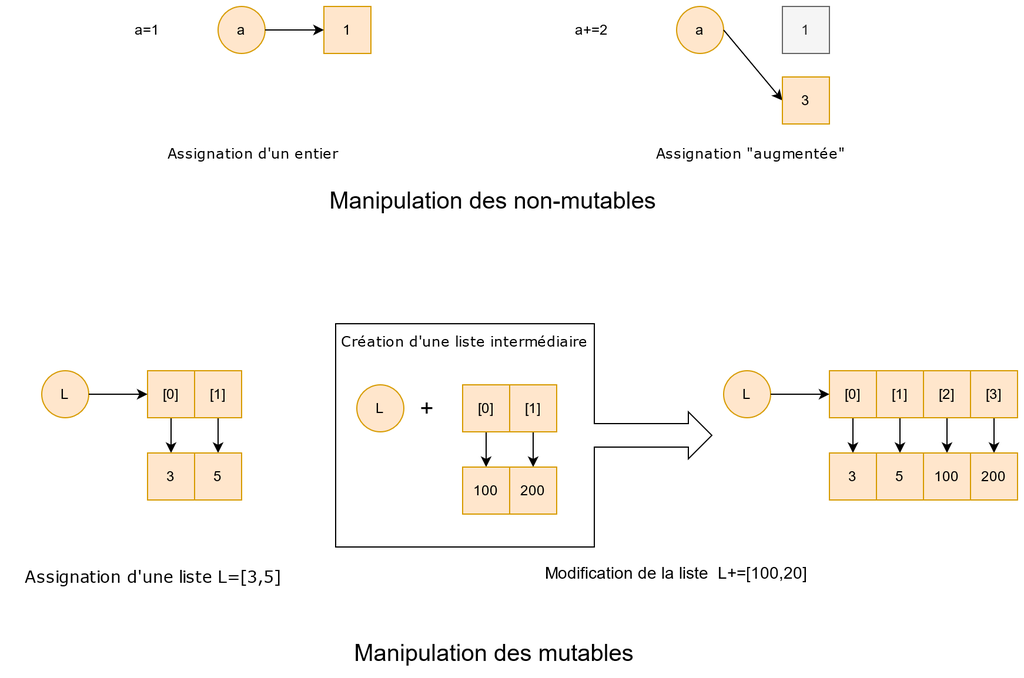

#### Les dictionnaires : "listes" clé/valeur

```python
valeur=10
dictionnaire={"clé":valeur,"recursif":[1,2,3]}
```

```python
dictionnaire["clé"]
```

```
10
```

```python
dic2=copy.copy(dictionnaire)
dic2["recursif"][1]=50
dic2["complex"]=1+2j #on enrichi le dictionnaire
print(dictionnaire)
print(dic2)
```

```
{'clé': 10, 'recursif': [1, 50, 3]}
{'clé': 10, 'recursif': [1, 50, 3], 'complex': (1+2j)}
```

> **⚠️ La "shallow" copy n'a créé de copie que pour le niveau supérieur.**

> Pour tout copier, on utilise `copy.deepcopy()`

```python
dictionnaire={"clé":valeur,"recursif":[1,2,3]}
dic2=copy.deepcopy(dictionnaire)
dic2["recursif"][1]=50
dic2["complex"]=1+2j #on enrichi le dictionnaire
print(dictionnaire)
print(dic2)
```

```
{'clé': 10, 'recursif': [1, 2, 3]}
{'clé': 10, 'recursif': [1, 50, 3], 'complex': (1+2j)}
```

```python
#on utilise l'opérateur ** pour "unpack" un dictionnaire, très utile pour en concaténer deux
new_dic={**dictionnaire,**{"var":1.2}}
print(new_dic)
```

```
{'clé': 10, 'recursif': [1, 2, 3], 'var': 1.2}
```

#### Le `tuple`, une liste non-mutable

```python
# exemple de tuple
vecteur=(1,0,0)
print(f"{vecteur=}, {type(vecteur)=}")
# vecteur[1]=2    —— c'est false
```

[output not shown]

L'opération précédente est illégale puisque le tuple n'est pas modifiable après sa création. Il faut réallouer la variable par un nouveau tuple contenant la valeur souhaitée.

```python
vecteur=(vecteur[0],vecteur[1],2)
print(vecteur)
```

```
(1, 0, 2)
```

```python
#que l'on peut remplacer par l'opération suivante
vecteur=(*vecteur[:1],10)
print(vecteur)
```

```
(1, 10)
```

#### Quelques autres types qui peuvent etre utile

- `set` est une collection itérable non ordonnée d’éléments hachables uniques
- module `collections`
  - `defaultdic` du propose des dictionnaires avec valeur par défaut
  - `counter` bien pratique pour des dictionnaires de dénombrement
- `deque` pour des listes à accés rapide des extrémités (*file,tas* )
- module `heapq` pour des opérations efficaces sur les tas

  > Plus d'infos dans *Programmation Python Avancée, X. Olive*

### Gestion de la mémoire

> *Contrairement aux langages plus bas niveau, python gère "automatiquement" la mémoire.* Il l'alloue et la libère tout seul.

#### Garbage collector

> si une donnée en mémoire n’est plus référencée, le *garbage collector* `gc` de Python la supprime automatiquement (car son nombre de références tombe à zéro)

```python
# 使用 sys.getrefcount() 方法获取对象的引用计数
import sys
donnee=[1,2,3]
print(sys.getrefcount(donnee)) # le texte lui meme plus le passage à getrefcount
```

```
2
```

```python
maliste=donnee
print(sys.getrefcount(donnee))
```

```
3
```

> la fonction `del` permet de supprimer une référence, pas son contenu.

```python
del(donnee)
```

```python
donnee
```

> Le contenu est nettoyé par le garbage collector **automatiquement**.

On peut néanmoins accéder au `gc` ainsi

```python
# 若被调用时不包含参数，则启动完全的垃圾回收。
# 可选的参数 generation 可以是一个整数，指明需要回收哪一代（从 0 到 2 ）的垃圾。
# 当参数 generation 无效时，会引发 ValueError 异常。返回发现的不可达对象的数目。
# 每当运行完整收集或最高代 (2) 收集时，为多个内置类型所维护的空闲列表会被清空。
# 由于特定类型特别是 float 的实现，在某些空闲列表中并非所有项都会被释放。
import gc
gc.collect() # fait le ménage
gc.get_threshold() # un second mécanisme "générationel" traite les récursions, avec les propriétés suivantes
# 将当前回收阈值以形为 (threshold0, threshold1, threshold2) 的元组返回。
```

```
(700, 10, 10)
```

#### Evaluation de l'usage mémoire

> *Pour des programmes complexes ou traitant de grandes données, on peut suivre l'usage mémoire par profiler*

Il existe une multitude de solution, la plupart vont aller chercher activement l'usage mémoire à interval regulier (ou lors des allocations) pour obtenir une bonne estimation de l'usage mémoire. Ici, on peut installer l'outil `memory_profiler` qui s'intègre facilement à jupyter.

```
!mamba install -c conda-forge memory_profiler -y
```

```python
%load_ext memory_profiler
```

```python
# que l'on appelle ensuite ainsi
%memit [i for i in range(100000)]
```

```
peak memory: 95.05 MiB, increment: 5.11 MiB
```

Il existe une version ligne par ligne `%mprun` qui ne fonctionne que pour les fonctions définies dans des fichiers externe. (cf TP)

## Programmation fonctionelle

### Fonctions

On défini une fonction de la façon suivante:

```python
# 在Python中，函数参数可以有默认值。
# 当你定义一个函数并为其中的某个参数提供了默认值时，这个参数就成为了一个可选参数
# 调用函数时可以选择不传递该参数的值，此时函数会使用默认值。
# 但是，如果你传递了一个具体的值给这个可选参数，那么这个传递的值将会覆盖默认值。
def fonc(x, y=0, *args, **kwargs):
    """Un docstring est fortement recommandé"""
    #do something
    print(f"{x:}, {y:}")
    print(x*y)
    return # même si on ne renvoie rien!
```

Que l'on appèlera ainsi:

```python
fonc(10,20)
#ou
fonc(10,y=20)
#ou, avec les arguments surnuméraires en supposant args et kwargs bien définis
# args=[]
# kwargs={}
# fonc(10,args, kwargs)
fonc(10)
print(fonc(10, 20))
```

```
10, 20
200
10, 20
200
10, 0
0
10, 20
200
None
```

Les arguments d'une fonction peuvent etres passés nommés ou non. S'ils ne le sont pas l'ordre est important.

#### Détails sur le passage des arguments

```
def fonc(x, y=0, *args, **kwargs):
    #actions
    return

>>> fonc(10,args, kwargs)
```

**Le passage se fait par assignation** et pas par références en soi. C'est à dire, qu'un nouvel alias est créé, pointant vers la case mémoire concernée. Deux cas de figure suivant que l'objet est:

1. **immutable** : toute modification dans le corps de la fonction entraine une nouvelle assignation/allocation.
2. **mutable** : toute modification dans le corps de la fonction entraine une modification de l'objet pointé. Donc de l'objet dans l'espace global.

> ⚠️ Ne pas utiliser des mutables en valeur par défaut. Leur durée de vie dépasse l'appel de la fonction!

```python
def ajout_liste(L=[],elem="elem"):
    #une liste inutile qui ajoute un élément à une liste
    L.append(elem)
    print(L)

ajout_liste(elem=1)
ajout_liste(elem=2)  #quel résultat est attendu?
```

```
[1]
[1, 2]
```

**Les fonctions sont des objets/variables comme les autres!**  
Mais on peut les appeler (callable).  
➡️ On peut passer une fonction comme argument

```python
def fonc2(fonc):
    return 2*(fonc(100))
```

On dispose même des *fonctions anonymes* `lambda function` qui sont définies à la volée, tant qu'elles sont mono-instruction.

```python
fonc2(lambda x: x+1)
```

```
202
```

En pratique on les utilisera seulement si l'instruction est très simple et facile à comprendre. Sinon on déclare une nouvelle fonction!

#### Type hinting `python>=3.5`

```
def hello_name(name: str) -> str:
    return(f"Hello {name}")
```

### Portée des variables

Variables locales, variables globales

- Les variables définies (ou passées) à la fonctions sont **locales** i.e. accessibles uniquement depuis la fonction et détruites ensuite.

```python
def fonc():
    y = "local"
    print(y)

fonc()
print(y)
```

- Les variables définies à l’extérieur d’une fonction sont des variables globales. Leur contenu est « visible » de l’intérieur d’une fonction, mais la fonction ne peut pas le modifier.

```python
x = "global"
def foo():
    print("x dedans:", x)

print("x dehors:", x)
```

```
x dehors: global
```

mais

```python
x = "global"

def foo():
    x = x * 2
    print(x)

foo()
```

On peut aussi utiliser (rarement) le mot clé `global` pour s'assurer que l'on modifie une variable globale du programme.

```python
x = "global "

def foo():
    global x # Essayer avec et sans!
    y = "local"
    x = x * 2   # copy 2 x
    print(x)
    print(y)

foo()
```

```
global global
local
```

Le cas `nonlocal` pour les fonctions imbriqués

```python
def outer():
    x = "local"

    def inner():
        nonlocal x
        x = "nonlocal"
        print("inner:", x)

    inner()
    print("outer:", x)


outer()
```

```
inner: nonlocal
outer: nonlocal
```

```python
def outer():
    x = "local"

    def inner():
        nonlocal x
        x = "non"+x    # 连接字符
        print("inner:", x)

    inner()
    print("outer:", x)


outer()
```

```
inner: nonlocal
outer: nonlocal
```

### Paradigme : La programmation fonctionnelle

#### *Un petit peu de théorie de la programmation*

**La programmation impérative** est le paradigme le plus répendu. On découpe le programme en une séquence d'instructions à exécuter. C'est une description de l'algo à exécuter pour résoudre le problème.  
🚀 Offre un bon controle de la performmance.

**La programmation déclarative** considère le programme par une description du problème. Le moteur du language met en oeuve l'algo permettant la résolution. C'est un paradigme de programmation sans *effet de bord* c.à.d. sans état interne permanent. Exemple : Latex, CSS.  
✔️ Formel donc permet de prouver que les résultats sont corrects.

**La programmation fonctionnelle** est une variante de programmation déclarative. La programmation est vue comme l'évaluation de fonctions mathématiques sans effet de bord.  
☞ Langages fonctionnels : Haskell, Scala, OCaml

**Par exemple:**

```python
L=[1,3,7,10,-1]
L.sort(), L
```

```
(None, [-1, 1, 3, 7, 10])
```

```python
L=[1,3,7,10,-1]
sorted(L), L
```

```
([-1, 1, 3, 7, 10], [1, 3, 7, 10, -1])
```

- La méthode `.sort` est impérative. Elle modifie l'input avec une série d'instructions.
- La fonction `sorted` suit un modèle fonctionnel, sans effet de bord. Deux appels successifs ne changent pas le résultat.

Un programme utile aura toujours des effets de bords, il interragit avec le monde extérieur.

Python n'est pas un langage fonctionnel. Cependant, les recommandations de la programmation fonctionnelle:

- limiter les effets de bord et états internes
- limiter les mutables
- programmation qui caractérise la solution plutot que la procédure

permettent un style modulaire et donc compsable.

**En pratique cela facilite aussi le teste et les débugs et certaines accélérations (jit, parallèlisme, GPU).**

Les bibliothèques `pandas` et `altair` ont une approche très fonctionnelle. `numpy` beaucoup moins comme on le verra.

#### Fonctions pures et d'ordre supérieur

Une **fonction pure** est une fonction dont le résultat dépend uniquement de ses arguments, donc sans effets de bord. En programmation foncitonnelle on utilise que des fonctions pures

Une **fonction d'ordre supérieur** est une fonction qui prend en argument une fonction ou renvoie une fonction.

**Exercice:** Ecrire une fonction pure `fibonacci`(et récursive) qui calcule le n-ème terme de la suite de Fibonacci.  
Rappel $f_0=1,f_1=1$ et $\forall n >1, \quad f_n=f_{n-1}+f_{n-1}$.

```python
# 把fib存入数组中，哈希表
def fibonacci(x: int) -> list[int]:
    a = []
    for i in range(x+1):
        if i == 0 or i == 1:
            a.append(1)
        else:
            a.append(a[i-1] + a[i-2])
    return a

print(fibonacci(10))
```

```
[1, 1, 2, 3, 5, 8, 13, 21, 34, 55, 89]
```

```python
def fibonacci(n: int)->int:
    if n in [0,1]: # condition d'arret
        return 1
    return(fibonacci(n-1)+fibonacci(n-2))
```

**Exercice:** Ecrire une fonction d'ordre supérieur `n_premiers` qui renvoie une fonction qui calcule les n permiers termes de la suite de Fibonacci.

```python
from typing import List
def n_premiers(func: "int -> int", n: int) -> List[int]:
    """Renvoie la liste des n premiers éléments de la suite de Fibonacci"""
    return [func(i) for i in range(n)]
```

```python
print(n_premiers(fibonacci,10))
```

[output not shown]

**Exercice:** Ecrire une fonction d'ordre supérieur `premiers` qui renvoie une fonction qui calcule les n permiers termes d'une suite et l'appliquer Fibonacci.

```python
def premiers(func: "int -> int") -> "int -> List[int]":
    """Renvoie une fonction qui calcule les n permiers termes."""
    def n_premiers_func(n: int) -> List[int]:
        return n_premiers(func,n)

    return n_premiers_func
```

```python
n_premiers_fibonacci=premiers(fibonacci)
n_premiers_fibonacci(10)
```

[output not shown]

### Deux mots sur les décorateurs

Un décorateur de fonction (d'ordre supérieur) est un outil qui permet de marquer une fonction afin d'en modifier le comportement. Il est marqué par le `@décorateur` avant une fonction.

```python
from time import time
def timer(func:"fonction")->"fonction":
    name=func.__name__

    def timed_func(*args):
        t1=time()
        arg_str=', '.join(repr(arg) for arg in args)
        resultat=func(*args)
        elapsed=time()-t1
        print(f"{name}({arg_str}) elapsed time [{elapsed:0.8f}s]")
        return resultat
    return timed_func
```

```python
@timer
def factorielle(n: int)->int:
    res=1
    for i in range(1,n):
        res*=i
    return res
```

```python
factorielle(20)
```

```
factorielle(20) elapsed time [0.00000000s]
```

```
121645100408832000
```

Attention aux fonctions réccursives, l'appel sera affiché à chaque fois!

```python
@timer
def factorielle_rec(n: int)->int:
    if n in [0,1]:
        return 1
    return n*factorielle_rec(n-1)
```

```python
factorielle_rec(20)
```

```
factorielle_rec(1) elapsed time [0.00000000s]
factorielle_rec(2) elapsed time [0.00000000s]
factorielle_rec(3) elapsed time [0.00000000s]
factorielle_rec(4) elapsed time [0.00000000s]
factorielle_rec(5) elapsed time [0.00000000s]
factorielle_rec(6) elapsed time [0.00000000s]
factorielle_rec(7) elapsed time [0.00000000s]
factorielle_rec(8) elapsed time [0.00000000s]
factorielle_rec(9) elapsed time [0.00000000s]
factorielle_rec(10) elapsed time [0.00000000s]
factorielle_rec(11) elapsed time [0.00000000s]
factorielle_rec(12) elapsed time [0.00000000s]
factorielle_rec(13) elapsed time [0.00000000s]
factorielle_rec(14) elapsed time [0.00000000s]
factorielle_rec(15) elapsed time [0.00000000s]
factorielle_rec(16) elapsed time [0.00000000s]
factorielle_rec(17) elapsed time [0.00000000s]
factorielle_rec(18) elapsed time [0.00000000s]
factorielle_rec(19) elapsed time [0.00000000s]
factorielle_rec(20) elapsed time [0.00000000s]
```

```
2432902008176640000
```

### Itérateurs et générateurs

> En programmation fonctionelle, la récursion joue souvent le role d'**itérateur** à la place des boucles `for`.

Si on voit l'itération comme *une structure générique qui fourni un service*, alors les structures itérables fournissent des élément un à un sans avoir à les charger intégralement en mémoire. On peut:

- les parcourir avec un `for`
- construire des structures en les *consommant*
- les manipuler par compréhension
- les déballer

```python
# range est un très bon exemple
range(10)
```

```
range(0, 10)
```

```python
type(range(10))
```

```
range
```

```python
for i in range(10):
    print(i)
```

```
0
1
2
3
4
5
6
7
8
9
```

```python
list(range(10))
```

```
[0, 1, 2, 3, 4, 5, 6, 7, 8, 9]
```

#### Retour sur l'écriture en compréhension

On peut utiliser les listes en compréhension pour créer des nouvelles structures et améliorer (un peu) la performance.

```python
%%timeit
L=[2*x**3 for x in range(1000000)]
```

```
312 ms ± 9.77 ms per loop (mean ± std. dev. of 7 runs, 1 loop each)
```

```python
%%timeit
L=[]
for x in range(1000000):
    L.append(2*x**3)
```

```
342 ms ± 8.07 ms per loop (mean ± std. dev. of 7 runs, 1 loop each)
```

#### Créer ses propres itérateurs avec le mot clé `yield`

> *Une fonction qui contient le mot-clé `yield` renvoie un générateur.*

Lorsqu'une fonction rencontre `yield`:

- elle renvoie la valeur courante
- attend la prochaine itération dans la boucle
- reprend le programme la ou il s'était arrété

La suite de Syracuse est définie ainsi:

Pour tout entier $n$, l'entier suivant est défini par $$ \mathrm{new} \; n = \begin{cases} \frac{n}{2} &\text{si } n \; \text{est pair} \\[4px] 3n+1 & \text{if } n \text{ sinon}.\end{cases}$$

**Exercice:** Ecrire un *générateur* de al suite de Syracuse grâce au mot-clé `yield`. Y ajouter une fonction qui calcule la longueur jusqu'à atteindre 1 `length` et celle qui donne la hauteur max `max`

```
>>> def syracuse(n: int)->"generator":
>>>    ...
>>>    yield n
>>>
>>> list(syracuse(10))
[10, 5, 16, 8, 4, 2, 1]
```

```python
def syracuse(n: int)->"generator":
    yield n #première itération, renvoie simplement l'input (pas de récursion ici)
    while n!=1: # le programme s'interrompt lorsque n=1, comme prévu
        if n%2==0:
            n=n//2
        else:
            n=3*n+1
        yield n # renvoie la nouvelle valeur de n à chaque passage
```

```python
list(syracuse(10))
```

```
[10, 5, 16, 8, 4, 2, 1]
```

```python
max(n for n in syracuse(27))
```

```
9232
```

```python
def length(iterable):
    return sum(1 for _ in iterable)
```

```python
length(syracuse(27))
```

```
112
```

```python
# trick
"->".join(str(i) for i in syracuse(27))
```

[output not shown]

**Pour aller plus loin :**

1. le module `itertools` permet des manipulations poussées des itérateurs
2. la fonction `next` renvoie la première valeur du générateur
3. les **coroutines** consomment des éléments à chaque appel

### Des "built-ins" et `functool`

#### `map`

**map(func, sequence)** applique une fonction à tous les éléments d'une séquence avec évaluation paresseuse (*lazy*).

```python
map(fibonacci,[1,10,20])
```

```
<map at 0x1cb529868b0>
```

```python
list(map(fibonacci,[1,10,20]))
```

```
[1, 89, 10946]
```

#### `filter`

**filter(func,x)** fonctionne de la même façon et renvoie les éléments de `x` pour lesquels `func` renvoie vrai.

```python
def paire(n:int)->bool:
    """Renvoie vrai si n est paire"""
    return(n%2==0)
list(filter(paire,[1,10,11]))
```

```
[10]
```

#### `reduce`

**reduce(func,x)** applique de façon cummulative la fonction `func` aux éléments de `x`.

```python
from functools import reduce
from operator import add
reduce(add,[1,10,100])
```

```
111
```

```python
#sum fait le meme travail...
sum([1,10,100])
```

```
111
```

Dans le meme esprit on a : `any` et `all` pour les opérations booléennes

## Programmation orientée objet

> Python est un langage fondamentalement orienté objet (OOP), les *classes*, *instances* et *méthodes* étant omniprésentes.

A reprendre au tableau

[figure not shown]

Quelques notions à avoir en tete avant de commencer :

- **encapsulation:** l'objet embarque toutes ses propriétés (varibales, méthodes) dans un espace de nommage
- **interface:** on part du service rendu qui est présenté à l'utilisateur pour concevoir la machinerie interne
- **factorisation:** on mutualisera au maximum les portions de code similaires grace aux concepts d'héritage et de composition

### Les classes

> On va suivre l'excellente présentation du livre de *Xavier Olive*, "Programmation python avancée" qui utilise les "Boids"

Un Boid (*bird-oid*) est une représentation simplifiée proposée par Craig Reynolds pour modéliser le comportement d'oiseaux avec les regles suivantes :

- de *séparation* pour préserver une distance minimum entre les individus
- de *cohésion* pour que les boids volent en groupe
- d'*alignement* pour qu'ils volent dans la meme direction

```python
%%HTML
<div align="middle">
<video width="80%" controls>
      <source src="../ressources/python/03-pythonic/15-objects/boids.mp4" type="video/mp4">
</video></div>
```

[video not shown]

#### Création d'une classe

```python
import numpy as np
class Boid:
    pass
```

```python
b=Boid()
b.x, b.y, b.v_x, b.v_y= 0,0, 1, 1
```

**Attention:** Il n'y a pas de notion d'attributs publics et privés en python !  
On utilisera des attribus pseudo privés notés par `_x`

Une *méthode* est une "fonction" définie dans le corps de la classe et qui vie dans son espace de nommage.

```python
class Boid:
    def module_vitesse(self):
        return np.sqrt(self.v_x**2+self.v_y**2)

b=Boid()
b.x, b.y, b.v_x, b.v_y= 0,0, 1, 1
b.module_vitesse()
```

```
1.4142135623730951
```

La méthode réservée `__init__` est le **constructeur** de la classe. Il est appelé chaque fois que cette classe est instanciée.

```python
class Boid:
    def __init__(self, position: tuple, vitesse: tuple)-> None:
        self.x, self.y=position
        self.v_x, self.v_y=vitesse

    def module_vitesse(self)->float:
        return np.sqrt(self.v_x**2+self.v_y**2)

    def avance(self) -> None:
        self.x += self.v_x
        self.y += self.v_y
```

```python
b=Boid((0,0),(1,2))
b.avance()
b  # b可不会输出结果
```

```
<__main__.Boid at 0x1cb52d0dac0>
```

`__repr__(self) -> str` définie une représentation de l'objet qui est renvoyée par l'interpréteur

`__str__(self) -> str` est l'affichage renvoyé par `print()`. Renvoie `__repr__` si non défini，打印一个类的实例对象时，会自动调用str方法，并返回回来一个字符串。str返回的不是一个字符串类型，是一个整形，因此会报错。此时，把(self.a) *(self.b)改成str((self.a)* (self.b))就可以了。

```python
class Boid:
    def __init__(self, position: tuple, vitesse: tuple)-> None:
        self.x, self.y=position
        self.v_x, self.v_y=vitesse

    def module_vitesse(self)->float:
        return np.sqrt(self.v_x**2+self.v_y**2)

    def avance(self) -> None:
        self.x += self.v_x
        self.y += self.v_y

    def __repr__(self)->str:
        return f"Boid({self.x,self.y}, {self.v_x,self.v_y})"
```

```python
b=Boid((0,0),(1,2))
b.avance()
b
```

```
Boid((1, 2), (1, 2))
```

On peut choisir de programmer des méthodes qui modifient ou non l'état interne.  
De même, on peut choisir des méthodes qui renvoient ou non un résultat.

**Arguments par défaut**. On veut pouvoir initialiser automatiquement nos instances (avec un peu de hasard). C'est l'idée programmatique de *factory*.

Une **variable de classe** est une variable qui est liée à la *classe* et non à l'*instance*.

```python
class Boid:

    taille = 300 # dimension du domaine des positions
    count = 0

    def __init__(self, position=None, vitesse=None) -> None:
        self.x = (
            position
            if position is not None
            else np.random.uniform(-Boid.taille, Boid.taille, 2)
        )
        self.dx = vitesse if vitesse is not None else np.random.uniform(-5, 5, 2)
        Boid.count +=1

    def __repr__(self) -> str:
        return f"Boid({self.x.round(2)}, {self.dx.round(2)}, parmi {Boid.count})"

    def vitesse(self)-> float:
        return np.linalg.norm(self.dx)
    def avance(self) -> "Boid":
        return Boid(self.x+self.dx, self.dx)

    def __del__(self): #on implémente un destructeur pour s'assurer que count est mis à jours correctement
        Boid.count-=1
        print('__del__ was called')
```

```python
b=Boid()
c=b.avance()
b, c
```

```
(Boid([-140.33  171.84], [-3.1   4.54], parmi 2),
 Boid([-143.43  176.38], [-3.1   4.54], parmi 2))
```

```python
b=0
del(b)
c=None
```

```python
Boid.count
```

```
2
```

☣️ Nous n'avons pas de contrôle direct sur le *garbage collector*. Le comportement est plus reproductible sur un appel python type `python file.py`

#### Décorer ses objets

A défaut d'attributs privés, on peut imposer certains comportements:

- `@property` définit un raccourcis qui s'utilise comme une variable. (utile de l'ustiliser avec `_var_name` pour "protéger" une variable.
- `@var_name.setter` pour pouvoir modifier la valeur de la variable

On défini une propriété `vitesse` de la façon suivante

```
@property
    def vitesse(self) -> float:
        return np.linalg.norm(self.dx)

    @vitesse.setter
    def vitesse(self, value: float) -> None:
        self.dx = self.dx * value / self.vitesse
```

De même il est parfois utile de définir une nouvelle façon d'initialiser une instance de notre classe. Le décorateur `@classmethod` le permet:

```
@classmethod
    def polaire(cls, r, theta, v, direction):
        return cls(r*np.array([np.cos(theta),np.sin(theta)]),v*np.array([np.cos(direction),np.sin(direction)]))
```

Enfin, on peut souhaiter encapsuler une "fonction" dans une classe par exemple pour controler sa visibilité. On utilisera le décorateur `@staticmethod` lors de la déclaration de la fonction.

```
@staticmethod
def scene(n:int) -> "list[Boid]":
    return [Boid() for _ in range(n)]
```

**Exercice : Make'em fly**  
Avec le squellette de classe fourni dans `boid_partial.py`, faire voler la nuée.

Appel pour exécuter le script et tracer la figure. La classe animation est déjà écrite.

```
fig, ax = plt.subplots(figsize=(7, 7))
simulation = Simulation(n=100, ax=ax)

anim = animation.FuncAnimation(
    fig,
    simulation.iteration,
    frames=range(0, 200),
    interval=150,
    blit=True,
    repeat=True,
)

anim.save("boids.mp4")
```

On pourra aussi jouer avec les variables de classes qui modifient le rapport de force entre les composantes qui dirigent le vol.

```
sep_coef=10
align_coef=8
cohere_coef=  100
centripete_coef= 200
```

### Héritage et composition

Une classe fille peut **hériter** des propriétés (et méthodes) d'une classe mère. Ceci permet de factoriser efficacement le code.

Attention, dans bien des cas, une relation de **composition** est plus judicieuse. Dans ce cas, un des attribus de la classe est un objet d'une autre classe.

```python
# exemple d'héritage:
class Personne:
    def __init__(self, nom, prenom, age):
        self.nom=nom
        self.prenom=prenom
        self.age=age

    def __repr__(self):
        return f"{self.nom} {self.prenom} ({self.age}ans)"

    def gen_ID(self):
        return (self.nom+self.prenom[0]).lower()

    def anniversaire(self):
        self.age+=1
        print("Joyeux anniversaire")

class Eleve(Personne): #La classe Eleve herite de toutes les proprietes de Personne
    def __init__(self, nom, prenom, age):
        super().__init__(nom, prenom, age)
        self.student_ID="S"+self.gen_ID()

    def __repr__(self):
        return super().__repr__()+f" {self.student_ID}"
```

```python
eleve=Eleve("Dupont", "Jean", 10)
```

```python
eleve
```

```
Dupont Jean (10ans) Sdupontj
```

```python
eleve.anniversaire()
eleve
```

```
Joyeux anniversaire
```

```
Dupont Jean (11ans) Sdupontj
```

```python
super(eleve).name
```

```python
#Exemple de composition
class Bulletin:
    def __init__(self, date, notes :"ndarray"):
        self.date=date
        self.notes=notes

    def moyenne(self):
        return np.average(notes)


class Eleve(Personne): #La classe Eleve herite de toutes les proprietes de Personne
    def __init__(self, nom, prenom, age):
        super().__init__(nom, prenom, age)
        self.student_ID="S"+self.gen_ID()
        self.bulletins=[]

    def __repr__(self):
        return super().__repr__()+f" {self.student_ID}"

    def meilleure_note(self):
        return np.array([B.notes for B in self.bulletins]).max()
```

```python
jean=Eleve("Dupont", "Jean", 10)
jean.bulletins.append(Bulletin("2021",np.array([10,11,2,1])))
jean.bulletins.append(Bulletin("2021",np.array([10,11,20,1])))
```

```python
jean.meilleure_note()
```

```
20
```

## Quelques conseils de structuration

### Bien comprendre le problème et le cahier des charges

- analyser le problème
- quels sont les objectifs
- quel structure générale est nécessaire
  - exécutable
  - script
  - API
- quelles sont les classes/variables de haut niveau
- choisir le bon environnement de travail

### Ebauche

- écrire un petit code test n'est pas interdit
- créer les grandes structures et fonctions en premier, quitte à les laisser vide mais commentées
- "*simple is beautiful"* -> zen of python

### Dev / Test

- si possible écrire les tests / appels API en premier -> contraint le dev dans la bonne direction
- test driven programming?
- s'assurer du bon fonctionnement des briques élémentaires au fur et à mesure

  **Rappel :** développer c'est environs 90% de débuggage  
  => Il faut **absolument** écrire du code lisible!!

### Vers un code en production : Optimisation et parallèlisme

- Optimisation
  - ne pas chercher à optimiser dès le départ
  - mais avoir en tête un ensemble de pratiques favorables
  - utiliser des outils de profiling
    1. Améliorer son code python / algo
    2. Utiliser (mieux) des libraries
    3. Chercher des améliorations techniques (JIT, langages compilés)
- Parallelisation
  - python n'est pas très propice au //
  - un bon code séquentiel est un prérequis absolu
  - dans quelques cas, on pourra avoir un gain de performance
  - pour les tableaux : calcul GPU